# Homework_answers

20059

2020/12/18

# Overview

In this file, all my homework answers are listed in the time order.

# HW0-2020-09-22

## Question 1

A graph

## Answer 1

Hello, this is my first R markdown document!

The figure is from the book *R for beginners* in page 49, which is shown as follows:

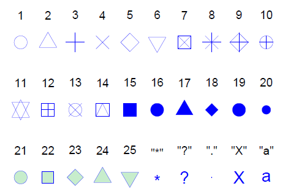

This is picture 1.

## Question 2

Including Tables

## Answer 2

Here is a table input, which is from the iris dataset:

| Sepal.Length | Sepal.Width | Petal.Length | Petal.Width | Species |
| --- | --- | --- | --- | --- |
| 5.1 | 3.5 | 1.4 | 0.2 | setosa |
| 4.9 | 3.0 | 1.4 | 0.2 | setosa |
| 4.7 | 3.2 | 1.3 | 0.2 | setosa |
| 4.6 | 3.1 | 1.5 | 0.2 | setosa |
| 5.0 | 3.6 | 1.4 | 0.2 | setosa |
| 5.4 | 3.9 | 1.7 | 0.4 | setosa |

[output not shown]

And this table is from the **mtcars** dataset:

|  | mpg | cyl | disp | hp | drat | wt | qsec | vs | am | gear | carb |
| --- | --- | --- | --- | --- | --- | --- | --- | --- | --- | --- | --- |
| Mazda RX4 | 21.0 | 6 | 160.0 | 110 | 3.90 | 2.620 | 16.46 | 0 | 1 | 4 | 4 |
| Mazda RX4 Wag | 21.0 | 6 | 160.0 | 110 | 3.90 | 2.875 | 17.02 | 0 | 1 | 4 | 4 |
| Datsun 710 | 22.8 | 4 | 108.0 | 93 | 3.85 | 2.320 | 18.61 | 1 | 1 | 4 | 1 |
| Hornet 4 Drive | 21.4 | 6 | 258.0 | 110 | 3.08 | 3.215 | 19.44 | 1 | 0 | 3 | 1 |
| Hornet Sportabout | 18.7 | 8 | 360.0 | 175 | 3.15 | 3.440 | 17.02 | 0 | 0 | 3 | 2 |
| Valiant | 18.1 | 6 | 225.0 | 105 | 2.76 | 3.460 | 20.22 | 1 | 0 | 3 | 1 |
| Duster 360 | 14.3 | 8 | 360.0 | 245 | 3.21 | 3.570 | 15.84 | 0 | 0 | 3 | 4 |
| Merc 240D | 24.4 | 4 | 146.7 | 62 | 3.69 | 3.190 | 20.00 | 1 | 0 | 4 | 2 |
| Merc 230 | 22.8 | 4 | 140.8 | 95 | 3.92 | 3.150 | 22.90 | 1 | 0 | 4 | 2 |
| Merc 280 | 19.2 | 6 | 167.6 | 123 | 3.92 | 3.440 | 18.30 | 1 | 0 | 4 | 4 |
| Merc 280C | 17.8 | 6 | 167.6 | 123 | 3.92 | 3.440 | 18.90 | 1 | 0 | 4 | 4 |
| Merc 450SE | 16.4 | 8 | 275.8 | 180 | 3.07 | 4.070 | 17.40 | 0 | 0 | 3 | 3 |
| Merc 450SL | 17.3 | 8 | 275.8 | 180 | 3.07 | 3.730 | 17.60 | 0 | 0 | 3 | 3 |
| Merc 450SLC | 15.2 | 8 | 275.8 | 180 | 3.07 | 3.780 | 18.00 | 0 | 0 | 3 | 3 |
| Cadillac Fleetwood | 10.4 | 8 | 472.0 | 205 | 2.93 | 5.250 | 17.98 | 0 | 0 | 3 | 4 |
| Lincoln Continental | 10.4 | 8 | 460.0 | 215 | 3.00 | 5.424 | 17.82 | 0 | 0 | 3 | 4 |
| Chrysler Imperial | 14.7 | 8 | 440.0 | 230 | 3.23 | 5.345 | 17.42 | 0 | 0 | 3 | 4 |
| Fiat 128 | 32.4 | 4 | 78.7 | 66 | 4.08 | 2.200 | 19.47 | 1 | 1 | 4 | 1 |
| Honda Civic | 30.4 | 4 | 75.7 | 52 | 4.93 | 1.615 | 18.52 | 1 | 1 | 4 | 2 |
| Toyota Corolla | 33.9 | 4 | 71.1 | 65 | 4.22 | 1.835 | 19.90 | 1 | 1 | 4 | 1 |
| Toyota Corona | 21.5 | 4 | 120.1 | 97 | 3.70 | 2.465 | 20.01 | 1 | 0 | 3 | 1 |
| Dodge Challenger | 15.5 | 8 | 318.0 | 150 | 2.76 | 3.520 | 16.87 | 0 | 0 | 3 | 2 |
| AMC Javelin | 15.2 | 8 | 304.0 | 150 | 3.15 | 3.435 | 17.30 | 0 | 0 | 3 | 2 |
| Camaro Z28 | 13.3 | 8 | 350.0 | 245 | 3.73 | 3.840 | 15.41 | 0 | 0 | 3 | 4 |
| Pontiac Firebird | 19.2 | 8 | 400.0 | 175 | 3.08 | 3.845 | 17.05 | 0 | 0 | 3 | 2 |
| Fiat X1-9 | 27.3 | 4 | 79.0 | 66 | 4.08 | 1.935 | 18.90 | 1 | 1 | 4 | 1 |
| Porsche 914-2 | 26.0 | 4 | 120.3 | 91 | 4.43 | 2.140 | 16.70 | 0 | 1 | 5 | 2 |
| Lotus Europa | 30.4 | 4 | 95.1 | 113 | 3.77 | 1.513 | 16.90 | 1 | 1 | 5 | 2 |
| Ford Pantera L | 15.8 | 8 | 351.0 | 264 | 4.22 | 3.170 | 14.50 | 0 | 1 | 5 | 4 |
| Ferrari Dino | 19.7 | 6 | 145.0 | 175 | 3.62 | 2.770 | 15.50 | 0 | 1 | 5 | 6 |
| Maserati Bora | 15.0 | 8 | 301.0 | 335 | 3.54 | 3.570 | 14.60 | 0 | 1 | 5 | 8 |
| Volvo 142E | 21.4 | 4 | 121.0 | 109 | 4.11 | 2.780 | 18.60 | 1 | 1 | 4 | 2 |

## Question 3

Latex Formulas

## Answer 3

The set of formulas is from the book **Statistical Computing with R** in Page.25, which lists the *properties of expected values and variance*:

$$\begin{equation}
1. E[ {aX + b} ] = aE[ X ] + b
\end{equation}$$

$$\begin{equation}
2. E[X + Y] = E[X] + E[Y]
\end{equation}$$

$$\begin{equation}
3. Var[aX + b] = a^2Var(X)
\end{equation}$$

$$\begin{equation}
4. Var(X + Y) = Var(X) + Var(Y) + 2Cov(X, Y)
\end{equation}$$

#### 5. If X and Y are independent, then

$$\begin{align*}
Var(X + Y) &= Var(X) + Var(Y) \\
E[XY] &= E[X]E[Y]
\end{align*}$$

# HW1-2020-09-22

## Question 1

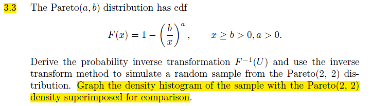

Question 1

## Answer 1

Firstly, we get the inverse function $F^{-1}(x)$ as follows:

Suppose $y=F(x)$, then there is
$$\begin{equation}
y = 1 - {\left( {\frac{b}{x}} \right)^a}
\end{equation}$$

We assume that
$$\begin{equation}
x = 1 - {\left( {\frac{b}{y}} \right)^a}
\end{equation}$$

and we get

$$\begin{equation}
y = \frac{b}{{\sqrt[a]{{1 - x}}}}
\end{equation}$$

Therefore,

$$\begin{equation}
{F^{ - 1}}\left( x \right) = \frac{b}{{\sqrt[a]{{1 - x}}}}
\end{equation}$$

When $a=2$ and $b=2$, we get the sample ($n=10000$) in the following:

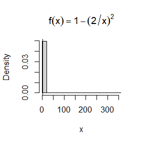

## Question 2

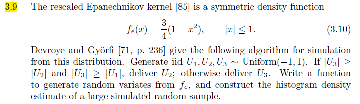

Question 2

## Answer 2

Suppose the function that generates random variates from $f_e$ is $F(x_1,x_2,x_3)$.

Suppose iid $x_1$, $x_2$, $x_3$ ~ $Uniform(-1,1)$, and we define the $F(x_1,x_2,x_3)$ as:

$$\begin{equation}
F({x_1},{x_2},{x_3}) = \left\{ {\begin{array}{*{20}{c}}
{{x_2},}&{\left| {{x_3}} \right| \ge \left| {{x_2}} \right|and\left| {{x_3}} \right| \ge \left| {{x_1}} \right|}\\
{{x_3},}&{otherwise}
\end{array}} \right.
\end{equation}$$

Then we get a large simulated random sample where $n=10000$:

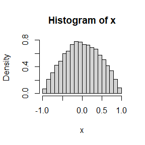

## Question 3

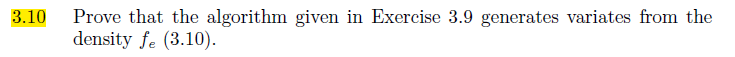

Question 3

## Answer 3

The CDF of $f_e$ is:

$$\begin{equation}
\begin{array}{c}
F(x) = \int_{ - \infty }^x {{f_e}\left( x \right)dx} \\
= \frac{3}{4}x - \frac{{{x^3}}}{4}
\end{array}
\end{equation}$$

The comparision is shown in the following:

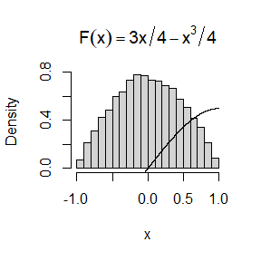

## Question 4

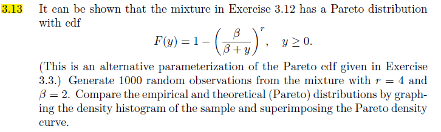

Question 4

## Answer 4

Firstly, we get the inverse function $F^{-1}(x)$ as follows:

$$\begin{equation}
{F^{ - 1}}(x) = \frac{\beta }{{{{(1 - x)}^{\frac{1}{r}}}}} - \beta
\end{equation}$$

We construct the the histogram density estimate of $f_e$ where $n=10000$ in the following:

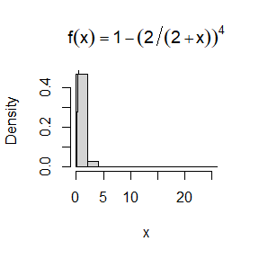

# HW2-2020-10-13

## Question 1

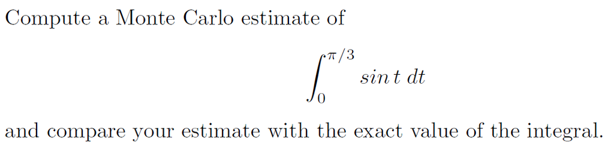

Question 1

## Answer 1

$$\int_{0}^{\frac{\pi}{3}}{\sin tdt} = \int_{0}^{\frac{\pi}{3}} {g(t)\frac{1}{{{\frac{\pi}{3}} - 0}}dt}$$

where
$$\begin{array}{c}
g(t) = ({\frac{\pi}{3}} - 0)\sin t \\
= \frac{\pi }{3}\sin t
\end{array}$$

Therefore,
$$\begin{equation}
\int_{0}^{\frac{\pi}{3}}{\sin tdt} = \frac{\pi }{3}E(\sin X)
\end{equation}$$

where

$$X \sim U (0,\frac{\pi }{3})$$

And the original value of the integral is:

$$\int_0^{\frac{\pi }{3}} {\sin tdt} = - \cos x\left| {\begin{array}{*{20}{c}}
{\frac{\pi }{3}}\\
0
\end{array}} \right.$$

```r
n <- 1e5
x <- runif(n, min=0, max=pi/3)
th <- mean(sin(x)) * pi/3
print(c(th,1-cos(pi/3)))
```

```
## [1] 0.5005948 0.5000000
```

## Question 2

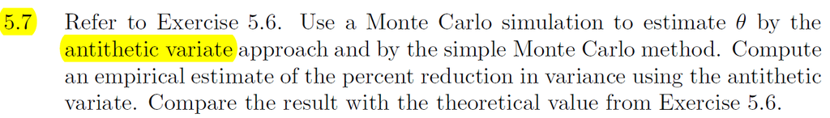

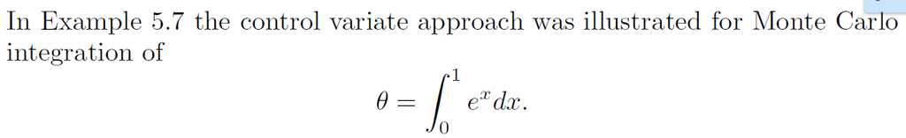

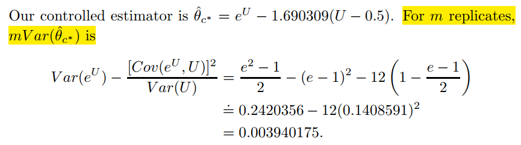

## Answer 2

where

$$X \sim U(0,1)$$

The antithetic variable estimator is:

$$\theta ' = \frac{1}{n}\sum\limits_{i = 1}^{\frac{n}{2}} {\left( {{e^{{X_i}}} + {e^{\left( {{\rm{1 - }}{X_i}} \right)}}} \right)}$$
where

$$X \sim U(0,1)$$

Therefore, the original value’s variance and the antithetic variable estimator’s variance is:

```r
MC.Phi <- function(x, R = 10000, antithetic = TRUE) {
  u <- runif(R/2,0,x)
  if (!antithetic) v <- runif(R/2,0,x) else v <- 1 - u
  g <- exp(u)+exp(v)
  cdf <- mean(g)
  cdf
}

m <- 1000
MC1 <- MC2 <- numeric(m)
x <- 1

for (i in 1:m) {
  MC1[i] <- MC.Phi(x, R = 1000, anti = FALSE)
  MC2[i] <- MC.Phi(x, R = 1000)
}


print(c(var(MC1),var(MC2),1-var(MC2)/var(MC1)))
```

```
## [1] 9.968066e-04 3.077646e-05 9.691249e-01
```

The theoretical value is:

```r
m <- 1000
MC1 <- MC2 <- MC3 <- MC4 <- numeric(m)
x <- 1

for (i in 1:m) {
  u <- runif(1000,0,1)
  MC1[i] <- mean(exp(u))
  v <- 1-u
  MC2[i] <- mean(exp(v))
  MC4[i] <- mean(u)
}



print(c(var(MC1+MC2),cov(MC1,MC2)))
```

```
## [1]  1.522122e-05 -2.410622e-04
```

```r
ves <- var(MC1)-cov(MC1,MC4)^2/var(MC4)

print(c(ves,var(MC1),1-ves/var(MC1)))
```

```
## [1] 3.866147e-06 2.487704e-04 9.844590e-01
```

## Question 3

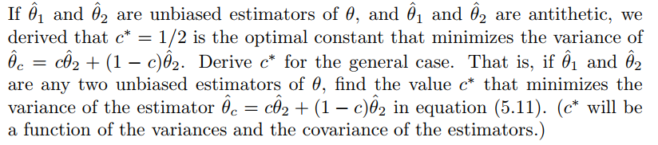

Question 3

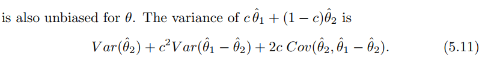

Question 3

## Answer 3

The function of $c$ is:

$$f(c) = Var({\hat \theta _2}) + {c^2}Var({\hat \theta _1} - {\hat \theta _2}) + 2cCov({\hat \theta _2},{\hat \theta _1} - {\hat \theta _2})$$

The optimal value is derived from $f'(c)=0$, which is:

$$f'(c) = 2cVar({\hat \theta _1} - {\hat \theta _2}) + 2Cov({\hat \theta _2},{\hat \theta _1} - {\hat \theta _2}) = 0$$

i.e.

$$c = - \frac{{Cov({{\hat \theta }_2},{{\hat \theta }_1} - {{\hat \theta }_2})}}{{Var({{\hat \theta }_1} - {{\hat \theta }_2})}}$$

# HW3-2020-10-20

## Question 1

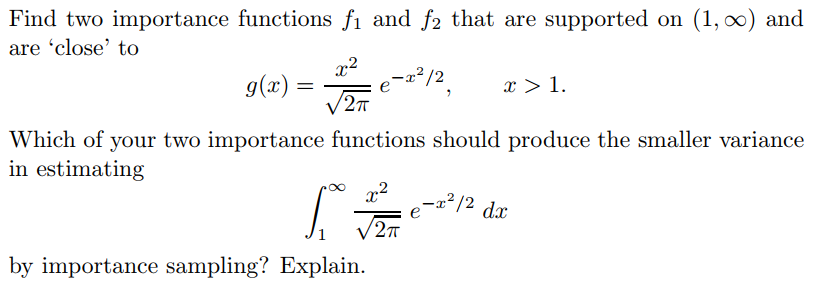

Question 1

## Answer 1

Suppose ${f_1}\left( x \right) = \frac{1}{{\sqrt {2\pi } }}{e^{ - \frac{{{x^2}}}{2}}}$ and ${f_2}\left( x \right) = {e^{ - x}}$, and their respective variances when serving as the important functions are listed in the follows:

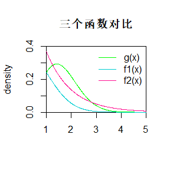

```r
m <- 10000
theta.hat <- se <- numeric(2)
g <- function(x) {
exp(-x^2/2)*(x^2)*(2*pi)^(-0.5)
}

x1 <- rnorm(m,0,1) #using f1
fg <- g(x1) / dnorm(x1)
theta.hat[1] <- mean(fg)
se[1] <- var(fg)

x2 <- rexp(m, 1) #using f1
fg <- g(x2) / exp(-x2)
theta.hat[2] <- mean(fg)
se[2] <- var(fg)

y <- seq(1, 5, .01)
s1 <- dnorm(y,0,1)
s2 <- exp(-y)
s3 <- g(y)


plot(y,s3,col="green",xlim=c(1,5),ylim=c(0,0.4),type='l',
     xaxs="i", yaxs="i",ylab='density',xlab='',
     main="三个函数对比")

lines(y,s1,col="DarkTurquoise")#lty=1表示用实线连起来

lines(y,s2,col="DeepPink")#lty=2表示用虚线连起来
legend.text=c(expression(paste("g(x)")),
expression(paste("f1(x)")),
expression(paste("f2(x)")))

legend("topright",legend=legend.text,
       lwd=1,col=c("green","DarkTurquoise","DeepPink"),bty='n')
```

```r
print(paste("The estimate of function 1 is: ",theta.hat[1]," and its variance is: ",se[1]))
```

```
## [1] "The estimate of function 1 is:  1.01246160526166  and its variance is:  1.93333189892767"
```

```r
print(paste("The estimate of function 2 is: ",theta.hat[2]," and its variance is: ",se[2]))
```

```
## [1] "The estimate of function 2 is:  0.501551044038105  and its variance is:  0.288883570633775"
```

```r
rbind(theta.hat, se)
```

```
##               [,1]      [,2]
## theta.hat 1.012462 0.5015510
## se        1.933332 0.2888836
```

Therefore, the function ${f_2}\left( x \right) = {e^{ - x}}$ produces a smaller variance as the importance function.

## Question 2

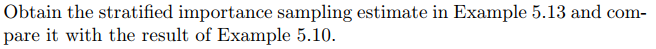

Question 2

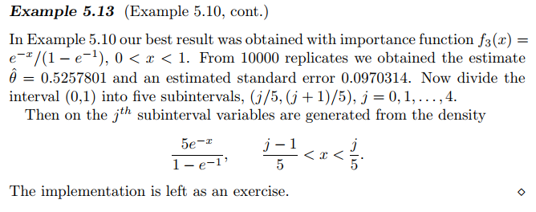

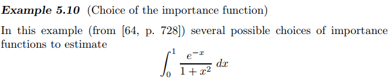

## Answer 2

The stratified importance sampling estimate in Example 5.13 is:

```r
M <- 10000
k <- 5 # what if k is larger?
N <- 50 #number of times to repeat the estimation
T2 <- numeric(k)
est <- matrix(0, N, 2)
f <-function(x) {
  5* exp(-x)/(1-exp(-1))
}
g <-function(x){
  exp(-x)/(1+x^2)
}



for (i in 1:N) {
u <- runif(M) #f3, inverse transform method
x <- - log(1-u * (1 - exp(-1)))
fg <- g(x) / (exp(-x) / (1 - exp(-1)))
est[i, 1] <- mean(fg)

for(j in 1:k) {
  u2 <- runif(M/k,(j-1)/k,j/k)
  x2 <- -log(1-(u2 * (1 - exp(-1)))/5)
  T2[j]<-mean(g(x2)/f(x2)) #the mean of each strata
}

est[i, 2] <- mean(T2)
}

est
```

```
##            [,1]      [,2]
##  [1,] 0.5230319 0.1256898
##  [2,] 0.5238014 0.1256879
##  [3,] 0.5243997 0.1256890
##  [4,] 0.5239282 0.1256847
##  [5,] 0.5261170 0.1256856
##  [6,] 0.5254537 0.1256860
##  [7,] 0.5235672 0.1256872
##  [8,] 0.5253582 0.1256869
##  [9,] 0.5234843 0.1256876
## [10,] 0.5242103 0.1256888
## [11,] 0.5245766 0.1256878
## [12,] 0.5267053 0.1256886
## [13,] 0.5261223 0.1256885
## [14,] 0.5245587 0.1256888
```

[output cut: 36 more lines]

```r
apply(est,2,mean)
```

```
## [1] 0.5249469 0.1256876
```

```r
apply(est,2,sd)
```

```
## [1] 1.085230e-03 1.691525e-06
```

## Question 3

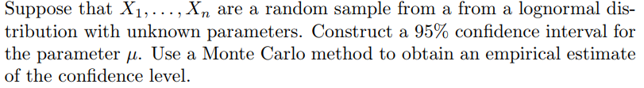

Question 3

## Answer 3

Given that $\ln X \sim N\left( {\mu ,{\delta ^2}} \right)$ and $\alpha = 0.05$ , suppose $Y=\ln X$ and $T = \frac{{\bar Y - \mu }}{ {{S_n^*} / {\sqrt n }}} \sim t\left( {n - 1} \right)$.

Since

$$P\left\{ {\left| T \right| \le {t_{\frac{\alpha }{2}}}\left( {n - 1} \right)} \right\} = 1 - \alpha,$$
$$\begin{equation}
\left| T \right| \le {t_{\frac{\alpha }{2}}}\left( {n - 1} \right) \Leftrightarrow \left| {\frac{{\bar Y - \mu }}{{{
{{S_n^*} / {\sqrt n }}} }}} \right| \le {t_{\frac{\alpha }{2}}}\left( {n - 1} \right),
\end{equation}$$

therefore, the 95% CI for parameter $\mu$ is:
$$\bar Y - \frac{{S_n^*}}{{\sqrt n }}{t_{\frac{\alpha }{2}}}\left( {n - 1} \right) \le \mu \le \bar Y + \frac{{S_n^*}}{{\sqrt n }}{t_{\frac{\alpha }{2}}}\left( {n - 1} \right),$$

where
$$\bar Y = \frac{1}{n}\sum\limits_{i = 1}^n {\ln {X_i}}$$
and

$$\begin{equation}
\begin{aligned}
S_n^* & = \sqrt {\frac{1}{{n - 1}}\sum\limits_{i = 1}^n {{{\left( {{Y_i} - \bar Y} \right)}^2}} } \\
& = \sqrt {\frac{1}{{n - 1}}\sum\limits_{i = 1}^n {{{\left( {\ln {X_i} - \frac{1}{n}\sum\limits_{i = 1}^n {\ln {X_i}} } \right)}^2}} } .
\end{aligned}
\end{equation}$$

## Question 4

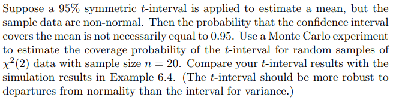

Question 4

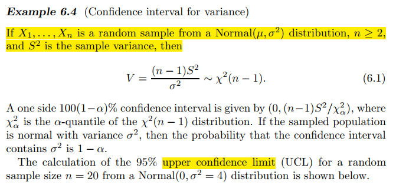

Question 4

## Answer 4

The MC estimate of the interval of ECP is:

```r
n <- 20
alpha <- .05
UCL <- replicate(1000, expr = {
x <- rchisq(n, df = 2)
mu <- 2
abs((mean(x)-mu)/(sd(x)/(n-1)^(0.5)))
} )
sum(UCL <= qt(1-alpha/2,df = n-1))
```

```
## [1] 916
```

```r
mean(UCL <= qt(1-alpha/2,df = n-1))
```

```
## [1] 0.916
```

Therefore, its ECP is much larger than that in Example 6.4.

# HW4-2020-10-27

## Question 1

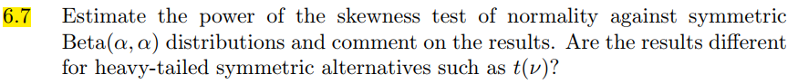

Question 1

### Beta分布用偏度检验正态性

```r
#compute the sample skewness statistic
sk <- function(x) {
#computes the sample skewness coeff.
xbar <- mean(x)
m3 <- mean((x - xbar)^3)
m2 <- mean((x - xbar)^2)
return( m3 / m2^1.5 )
}

#power test
n <- 30
m <- 1000
mu0 <- 500
sigma <- c(100,80,40,20,10,5,2)
mu <- c(100,80,40,20,10,5,2) #alternatives
M <- length(mu)
power <- numeric(M)
cv <- qnorm(0.95,0,sqrt(6/n))
for (i in 1:M) {
mu1 <- mu[i]
sig <- sigma[i]
#simulate under alternative mu1

#n is a vector of sample sizes
sktests <- numeric(m) #test decisions
for (j in 1:m) {
#test decision is 1 (reject) or 0
x <- rbeta(n, mu1, sig)
sktests[j] <- as.integer(abs(sk(x)) >= cv )
}
power[i] <- mean(sktests) #proportion rejected
}

rbind(sigma, power)
```

```
##          [,1]   [,2]   [,3]   [,4]   [,5]  [,6]  [,7]
## sigma 100.000 80.000 40.000 20.000 10.000 5.000 2.000
## power   0.063  0.066  0.055  0.059  0.035 0.019 0.006
```

### t分布用偏度检验正态性

```r
#compute the sample skewness statistic
sk <- function(x) {
#computes the sample skewness coeff.
xbar <- mean(x)
m3 <- mean((x - xbar)^3)
m2 <- mean((x - xbar)^2)
return( m3 / m2^1.5 )
}

#power test
n <- 30
m <- 1000
df<- c(100,80,40,20,10,5,2) #alternatives
M <- length(df)
power <- numeric(M)
cv <- qnorm(0.95,0,sqrt(6/n))
for (i in 1:M) {
df1 <- df[i]

#simulate under alternative mu1

#n is a vector of sample sizes
sktests <- numeric(m) #test decisions
for (j in 1:m) {
#test decision is 1 (reject) or 0
x <- rt(n,df1)
sktests[j] <- as.integer(abs(sk(x)) >= cv )
}
power[i] <- mean(sktests) #proportion rejected
}

rbind(df,power)
```

```
##          [,1]   [,2]   [,3]   [,4]   [,5]  [,6]  [,7]
## df    100.000 80.000 40.000 20.000 10.000 5.000 2.000
## power   0.093  0.074  0.096  0.134  0.155 0.288 0.616
```

## Question 2

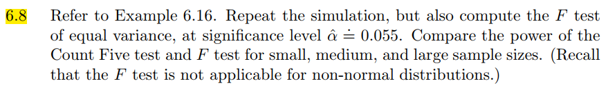

Question 2

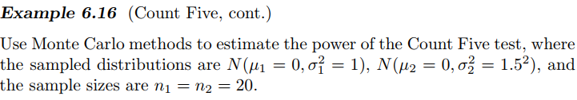

Question 2

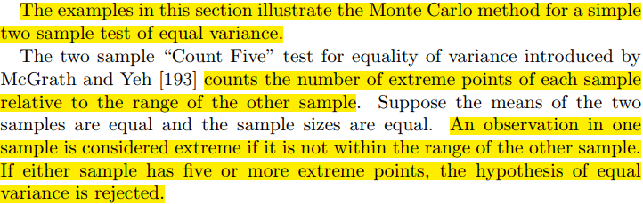

Question 3

## Answer 2

#### The Count Five Test is:

```r
count5test <- function(x, y) {
X <- x - mean(x)
Y <- y - mean(y)
outx <- sum(X > max(Y)) + sum(X < min(Y))
outy <- sum(Y > max(X)) + sum(Y < min(X))
# return 1 (reject) or 0 (do not reject H0)
return(as.integer(max(c(outx, outy)) > 5))
}
n1 <- n2 <- c(100,50,20)
n <- 3
mu1 <- mu2 <- 0
sigma1 <- 1
sigma2 <- 1.5
m <- 1000
# generate samples under H0
pr <- numeric(n)
for (i in n){
  power<- numeric(m)
  for (j in m){
  x <- rnorm(n1[i], mu1, sigma1)
  y <- rnorm(n2[i], mu2, sigma2)
  power[j] <- count5test(x, y)
  }
  pr[i] <- mean(power)
}


pr
```

```
## [1] 0 0 0
```

```r
rbind(n1,pr)
```

```
##    [,1] [,2] [,3]
## n1  100   50   20
## pr    0    0    0
```

#### The F Test is:

```r
Ftest <- function(x, y) {
X <- sd(x)
Y <- sd(y)
n <- length(x)-1
m <- length(y)-1
f1 <- as.integer(X/Y < qf(0.055/2, n, m))
f2 <- as.integer(X/Y > qf(1-0.055/2, n, m))
# return 1 (reject) or 0 (do not reject H0)
return(max(f1,f2))
}

n1 <- n2 <- c(100,50,20)
mu1 <- mu2 <- 0
sigma1 <- 0
sigma2 <- 1.5
m <- 1000
n <- 3
fpr <- numeric(n)
# generate samples under H0
for (i in n){
  fpower<- numeric(m)
  for (j in m){
  x <- rnorm(n1[i], mu1, sigma1)
  y <- rnorm(n2[i], mu2, sigma2)
  fpower[j] <- Ftest(x, y)
  }
  fpr[i] <- mean(fpower)
}


fpr
```

```
## [1] 0.000 0.000 0.001
```

```r
rbind(n1,fpr)
```

```
##     [,1] [,2]  [,3]
## n1   100   50 2e+01
## fpr    0    0 1e-03
```

## Question 3

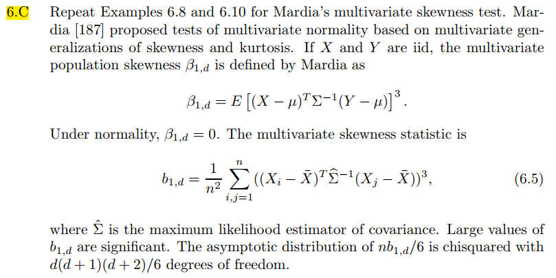

Question 3

## Answer 3

#### The Example 6.8 for multivariate skewness test is:

```r
sk <- function(m,nv) {
  beta <- numeric(1000)
  mu <- numeric(nv)
  for (j in 1:1000) {
  mu <- numeric(2)
  x <- rnorm(m)
  y <- rnorm(m)
  mu[1] <- mean(x)
  mu[2] <- mean(y)
  cxy <- solve(cov(x,y))
  X <- cbind(x,y)
  beta[i]<-(t(X[1]-mu[1])%*%cxy%*%(X[2]-mu[2]))^3
  }

#computes the sample skewness coeff.
#
return( sum(beta)/1000^2)
}
nv <- 2
n <- c(10, 20, 30, 50, 100, 500) #sample sizes
 #crit. values for each n
#n is a vector of sample sizes
#we are doing length(n) different simulations
p.reject <- numeric(length(n)) #to store sim. results
m <- 10000 #num. repl. each sim.
for (i in 1:length(n)) {
 #test decisions
sktests <- numeric(m)
#test decision is 1 (reject) or 0
cv1 <- qchisq(.975,n[i]*(n[i]+1)*(n[i]+2)/6)
cv2 <- qchisq(.025,n[i]*(n[i]+1)*(n[i]+2)/6)
for (j in m){
s <- sk(n[i],nv)*n[i]/6
s1 <- as.integer(abs(s) >= cv1)
s2 <- as.integer(abs(s) <= cv2)
sktests[j] <- max(s1,s2)
}
p.reject[i] <- mean(sktests) #proportion rejected
}

rbind(n,p.reject)
```

```
##           [,1]  [,2]  [,3]  [,4]  [,5]  [,6]
## n        1e+01 2e+01 3e+01 5e+01 1e+02 5e+02
## p.reject 1e-04 1e-04 1e-04 1e-04 1e-04 1e-04
```

#### The Example 6.10 for multivariate skewness test is:

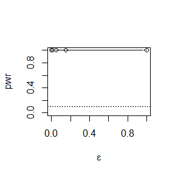

```r
sk2 <- function(n,sigma) {
  beta <- numeric(1000)
  mu <- numeric(2)
  for (j in 1:1000) {
  mu <- numeric(2)
  x <- rnorm(n, 0, sigma)
  y <- rnorm(n, 0, sigma)
  mu[1] <- mean(x)
  mu[2] <- mean(y)
  cxy <- solve(cov(x,y))
  X <- cbind(x,y)
  beta[i]<-(t(X[1]-mu[1])%*%cxy%*%(X[2]-mu[2]))^3
  }

#computes the sample skewness coeff.
#
return( sum(beta)/1000^2)
}


alpha <- .1
n <- 30
m <- 1000
epsilon <- c(0, .15, .01, 1, .05)
N <- length(epsilon)
pwr <- numeric(N)
#critical value for the skewness test
cv1 <- qchisq(.975,n*(n+1)*(n+2)/6)
cv2 <- qchisq(.025,n*(n+1)*(n+2)/6)
for (j in 1:N) { #for each epsilon
e <- epsilon[j]
sktests <- numeric(m)
for (i in 1:m) { #for each replicate
sigma <- sample(c(1, 10), replace = TRUE,
size = 1, prob = c(1-e, e))
s <- sk2(n,sigma)*n/6
s1 <- as.integer(abs(s) >= cv1)
s2 <- as.integer(abs(s) <= cv2)
sktests[i] <- max(s1,s2)
}
pwr[j] <- mean(sktests)
}
#plot power vs epsilon
plot(epsilon, pwr, type = "b",
xlab = bquote(epsilon), ylim = c(0,1))
abline(h = .1, lty = 3)
se <- sqrt(pwr * (1-pwr) / m) #add standard errors
lines(epsilon, pwr+se, lty = 3)
lines(epsilon, pwr-se, lty = 3)
```

```r
rbind(epsilon,pwr)
```

```
##         [,1] [,2] [,3] [,4] [,5]
## epsilon    0 0.15 0.01    1 0.05
## pwr        1 1.00 1.00    1 1.00
```